O código-fonte deste notebook IPython é oculto por padrão para facilitar a leitura. para mostrar/ocultar código fonte, clique aqui.

[figure not shown]

# Score de Prospecção

> Este relatório apresenta uma analise complementar ao relatório DataAnalytics 1.0. Tendo como foco analisar outras variaveis e o impacto delas no modelo, este relatório nao irá se ater a conceitos presentes no relatório anterior

## Problemática

> Dado o problema do baixo volume de dados diagnosticádo no ultimo relatório, esse trabalho irá aproveitar as variaveis já encontradas encontradas:
> - Consultas de Crédito;
> - Consultas Recentes;
> - Total de Consultas;
> - Evolução de Compromissos;
> - Historico de Pagamentos.

> E irá adicionar 6 novos parámetros, representando a presença(**1**) e ausencia(**0**) daquela informção em cada variável(**CNPJ**), sendo eles:
> - REFIN
> - PEFIN
> - DIVIDA VENCIDA
> - FALENCIA
> - AÇÃO JUDICIAL
> - PROTESTO

Amostra da base utizada:

|  | cnpj | txt_file | y | REFIN | PEFIN | DIVIDA VENCIDA | FALENCIA | ACAO JUDICIAL | PROTESTO | ConsultasCredito | ConsultasRecentes | Total_Consultas | EvolucaoCompromissos | HistoricoPagamentos |
| --- | --- | --- | --- | --- | --- | --- | --- | --- | --- | --- | --- | --- | --- | --- |
| 0 | 95.816.963/0001-74 | SERASA-R1059038.txt | 0.0 | 1 | 1 | 1 | 1 | 1 | 1 | 0.0 | 0 | 187 | 4.6 | -1.0 |
| 1 | 03.943.986/0001-21 | SERASA-R1084436.txt | 1.0 | 0 | 0 | 0 | 0 | 0 | 0 | 0.0 | 0 | 207 | 2.6 | 0.0 |
| 2 | 13.056.177/0003-13 | SERASA-R1109513.txt | 0.0 | 0 | 0 | 0 | 0 | 0 | 1 | 0.0 | 0 | 878 | 4.4 | -1.0 |
| 3 | 78.099.777/0001-42 | SERASA-R1146803.txt | 1.0 | 0 | 1 | 1 | 0 | 0 | 1 | 0.0 | 1 | 561 | 4.4 | -1.0 |
| 4 | 00.325.400/0001-77 | SERASA-R114892.txt | 0.0 | 1 | 1 | 0 | 0 | 0 | 1 | 0.0 | 0 | 177 | 4.6 | -1.0 |

## Análise e Treinamento

> Aqui apresentamos a matriz de correlação entre as variáveis. Importante salientar as relacionadas com o nosso *target*(**y**). Facilmente podemos ver que o resultado tem pouquissima relaçao com os parametros, exceto as informações de **HistoricoPagamentos** e **ConsultasRecentes** com uma correlação de aproximadamente **0.3**, sendo considerada uma relação baixa.

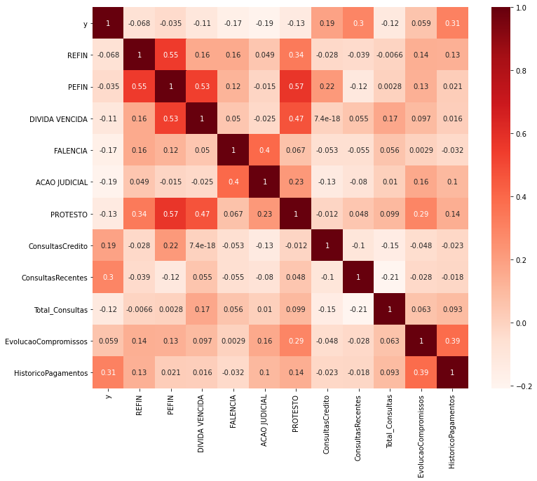

# XGBClassifier

## Árvore de Decisão (*Decission Tree*)

[figure not shown]

> O método de *Decission Tree* utiliza uma estrutura de árvore para determinar uma saida(representada por cada folha da árvore), através de diversas decisões encontradas em cada nó (ramificações ou galhos da árvore). Para montar uma árvore, é analisada a base de dados de entrada e gerada a sequência de perguntas e decisões tomadas. Sendo assim, uma mesma base pode gerar árvores diferentes com resultados igualmente diferentes, variando apenas a ordem das decisões tomadas. Dessa forma, surge a pergunta, como decidir e encontrar a melhor árvore ?

> Para isso é utilizado o Gradiente Descendente, que, de forma simplificada, combina diversas árvores "fracas" para gerar algo como um "comitê de decisão".

> Sendo assim, abaixo podemos visualizar os resultados encontrado pelo modelo

[output not shown]

> > - Accuracy: **0.86**

> > - Precisão: **0.86**

> > Apesar dos resultados "piores" aos encontrados em Data Analytics 1.0, vale salientar que mais parametros foram utilizados podendo diminuir o desempenho do modelo para esse conjunto de dados. Entretanto para o intuito deste estudo uma accuracy de 86% demonstra ser satisfatória.

> > **Matriz de Confusão:**

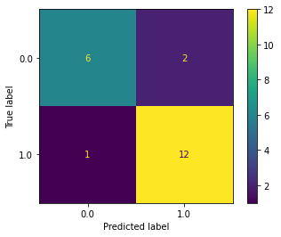

# Análise e Interpretação do Modelo

> Nessa etapa se encontra o ponto chave desse relátorio, a utilização do Shap para analizar os resultados do modelo e encontrar informações uteis para o negocio e para etapas futuras.

## SHAP

> O *SHapley Additive ex**P**lanations *é uma abordagem baseada em teoría dos jogos para explicar a saída de qualquer modelo de* Machine Learning*. Ele atribui o valor de cada parâmetro com os valores de* Shaply *da teoría dos jogos e sua relações entre as varíaveis. De forma simplificada, o SHAP tenta encontrar os valores de* Shaply* para cada variavel. Que nada mais são do que a representação numerica de quanto o valor daquela variável influenciou na decisão do modelo de forma positiva ou negativa.

## *Summary Plot*

> > Abaixo é apresentado o Summary Plot, nele podemos ver todas as variaveis em ordem de influencia no modelo, sendo o **HistoricoPagamentos** a que mais influencia e a **FALENCIA** a que menos influencia.

> > No eixo X é representado o SHAP value sitado a cima, quanto maior ele for, mais ele influencia para um resultado positivo(y = 1) e quanto menor mais ele influencia para um resultado negativo(y = 0). Além disso, as cores representam o valor de cada váriavel, azul um valor baixo e vermelho um valor alto.

### Interpretação

> > É possivel verificar que quando o **HistóricoPagamento** possui um valor baixo, ele quase sempre influencia o modelo e dizer que será um y = 0.

> > Outro ponto a ser analisado é que das variaveis binarias adicionadas, a que mais influencia no modelo de forma negativo quando presente no documento é a informação de **PROTESTO** seguida logo abaixo da **PEFIN** que sempre que presente, impacta no modelo para decisões positivas. Esse comportamento pode ser justificado por essas 2 variaveis binárias mais presentes no documento(Como visto em Data Analytics 1.0).

> > Por fim, a **EvoluçãoCompromissos** sempre que possui um valor baixo ela impacta no modelo para um resultado positívo

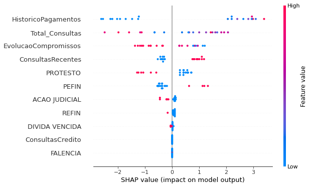

## *Dependence Plot*

> Outra fomra de visualizar as informações do grafico acima é através do *Dependence Plot*, que apresenta os valores de cada variável e o quanto eles influenciam no SHAP Value

### HistoricoPagamentos

> > Podemos verificar que valores abaixo de 0 sempre impactam em um resultado negativo, e valores acima disso impactam de ofrma possitiva.

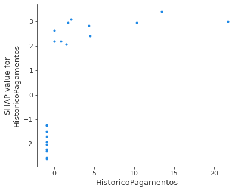

```
None
```

### ConsultaRecentes

> > Aqui verificamos que quando zerado a ConsultaRecentes, o modelo sempre é impactado para ser negativo. Sendo o oposto verdade.

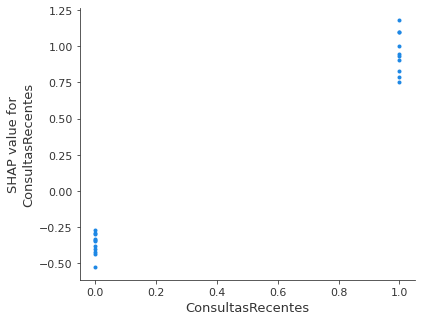

```
None
```

# Conclusões

Dado a quantidade de dados, verificamos os impactos de cada variavel e o quanto ela influencia em um modelo com 86% de accuracy. Chegamos a conclusão que as variaveis binarias adicionadas **PROTESTO** e **PEFIN** influenciaram de fomra positiva ao modelo, entretanto a baixa influencia das outras variaveis não dispensa a utilização delas, apenas que possue um desbalanceamento nos dados encontrados.